# GLMTREEAMOUNT

2023-04-12

```r
#install.packages("party")
#install.packages("partykit")
```

```r
library(zoo)
library(xts)
library(sp)
library(CASdatasets)
library(party)
library(partykit)
library(dplyr)
data(freMPL5)
```

## Traitement des données

```r
#enlever les valeurs négatives
freMPL5 <- subset(freMPL5, freMPL5$ClaimAmount >= 0)

#passer en variables catégorielles
freMPL5$HasKmLimit <- factor(freMPL5$HasKmLimit)
freMPL5$ClaimInd <- factor(freMPL5$ClaimInd)

#segmentation des tranches d'âge
freMPL5$DrivAge_fact <- cut(freMPL5$DrivAge, c(20,25,30,35,40,45,50,58,65,120), include.lowest = TRUE)

#Découpage CSP
freMPL5$Categ <-  ifelse(freMPL5$SocioCateg %in% c("CSP46","CSP48"), "Categ1",
ifelse(freMPL5$SocioCateg %in% c("CSP50","CSP55"), "Categ2",
ifelse(freMPL5$SocioCateg %in% c("CSP60"),"Categ3",
ifelse(freMPL5$SocioCateg %in% c("CSP42","CSP1", "CSP66"),"Categ4","Categ0"))))
freMPL5$Categ = factor(freMPL5$Categ)

#découpage RiskArea
freMPL5$RiskArea <- ifelse(freMPL5$RiskArea %in% c(1,2,3,12,13), "ZoneRisque1",
ifelse(freMPL5$RiskArea %in% c(5,6,7,8,9), "ZoneRisque2",
ifelse(freMPL5$RiskArea %in% c(10,11), "ZoneRisque3",
ifelse(freMPL5$RiskArea %in% c(4), "ZoneRisque4", NA))))

freMPL5$RiskArea <- factor(freMPL5$RiskArea)
```

```r
summary(freMPL5$RiskArea)
```

```
## ZoneRisque1 ZoneRisque2 ZoneRisque3 ZoneRisque4
##         905       16378        7547         892
```

```r
cout <- freMPL5[freMPL5$ClaimInd == 1,]
```

```r
cout2 <- subset(cout, cout$ClaimAmount <20000)
set.seed(123)
perm <- sample(nrow(cout2),80/100*nrow(cout2))
trainGLM.data <- cout2[perm,]
testGLM.data  <- cout2[-perm,]
```

### Méthode de Tukey

```r
# Calculer l'écart interquartile (IQR)
iqr_1 <- IQR(trainGLM.data$ClaimAmount)

# Calculer les bornes de la méthode de Tukey
lower_bound_1 <- quantile(trainGLM.data$ClaimAmount, 0.25) - 1.5*iqr_1
upper_bound_1 <- quantile(trainGLM.data$ClaimAmount, 0.75) + 1.5*iqr_1

# Identifier les outliers
outliers_tukey_valeurs_1 <- trainGLM.data$ClaimAmount[trainGLM.data$ClaimAmount < lower_bound_1 | trainGLM.data$ClaimAmount > upper_bound_1]

#On extrait les indices de ces outliers
outliers_tukey_indices_1 <- which(trainGLM.data$ClaimAmount < lower_bound_1 | trainGLM.data$ClaimAmount > upper_bound_1)

# Afficher les résultats
  #outliers_tukey_valeurs_1
  #length(outliers_tukey_valeurs_1)
# outliers_tukey_indices_1

#On enlèves ces outliers de notre échantillon

train_Tukey <- slice(trainGLM.data,-outliers_tukey_indices_1)
```

## II) GLM Tree lognormale

### A) Lien identité

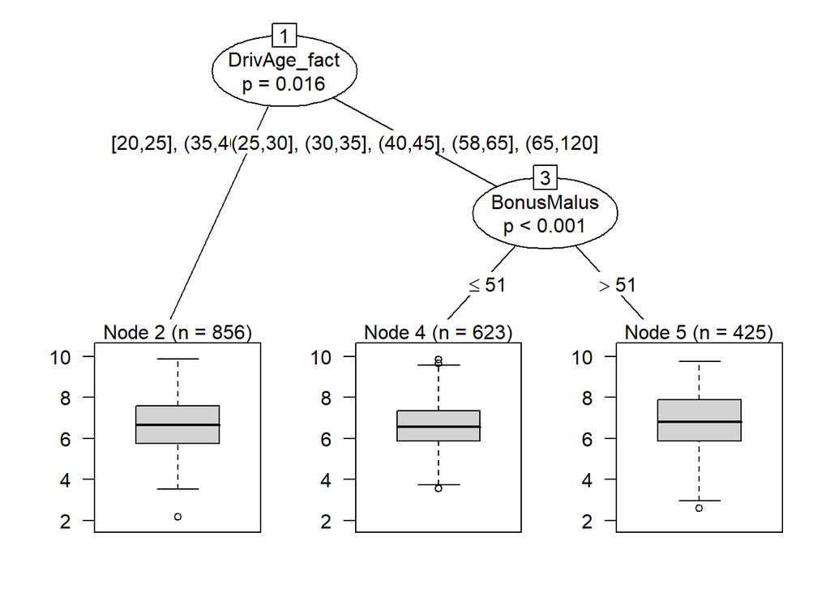

```r
glm_tree_lognorm_id <- glmtree(log(ClaimAmount) ~ MariStat+Categ+VehUsage+HasKmLimit+ClaimNbResp+ClaimNbNonResp+ClaimNbParking+ClaimNbFireTheft+ClaimNbWindscreen+OutUseNb+RiskArea+BonusMalus+DrivAge_fact|MariStat+Categ+VehUsage+HasKmLimit+ClaimNbResp+ClaimNbNonResp+ClaimNbParking+ClaimNbFireTheft+ClaimNbWindscreen+OutUseNb+RiskArea+BonusMalus+DrivAge_fact,
  data = trainGLM.data, maxdepth = 7, family = gaussian(link = "identity"))

plot(glm_tree_lognorm_id)
```

Regardons les modèles obtenus à chacun des noeuds terminaux

```r
summary(glm_tree_lognorm_id)
```

```
## $`2`
##
## Call:
## glm(formula = log(ClaimAmount) ~ MariStat + Categ + VehUsage +
##     HasKmLimit + ClaimNbResp + ClaimNbNonResp + ClaimNbParking +
##     ClaimNbFireTheft + ClaimNbWindscreen + OutUseNb + RiskArea +
##     BonusMalus + DrivAge_fact)
##
## Coefficients: (5 not defined because of singularities)
##                                 Estimate Std. Error t value Pr(>|t|)
## (Intercept)                     7.316895   0.509286  14.367  < 2e-16 ***
## MariStatOther                  -0.516735   0.160201  -3.226 0.001306 **
## CategCateg1                    -0.672814   0.276769  -2.431 0.015269 *
## CategCateg2                    -0.309617   0.219258  -1.412 0.158290
## CategCateg3                    -1.363091   0.460910  -2.957 0.003190 **
## CategCateg4                    -0.512466   0.243081  -2.108 0.035311 *
## VehUsagePrivate+trip to office -0.584431   0.155831  -3.750 0.000189 ***
## VehUsageProfessional           -0.148008   0.190779  -0.776 0.438083
## VehUsageProfessional run       -0.125892   0.262437  -0.480 0.631564
## HasKmLimit1                     0.861918   0.309151   2.788 0.005424 **
## ClaimNbResp                     0.168809   0.092610   1.823 0.068693 .
## ClaimNbNonResp                  0.102676   0.069290   1.482 0.138764
## ClaimNbParking                  0.214183   0.140330   1.526 0.127318
## ClaimNbFireTheft                0.164921   0.144927   1.138 0.255466
## ClaimNbWindscreen               0.005953   0.064645   0.092 0.926653
## OutUseNb                       -0.110600   0.061958  -1.785 0.074610 .
## RiskAreaZoneRisque2            -0.007880   0.251807  -0.031 0.975044
## RiskAreaZoneRisque3            -0.015002   0.259682  -0.058 0.953944
## RiskAreaZoneRisque4             0.026291   0.342291   0.077 0.938795
## BonusMalus                      0.002485   0.004095   0.607 0.544147
## DrivAge_fact(25,30]                   NA         NA      NA       NA
## DrivAge_fact(30,35]                   NA         NA      NA       NA
## DrivAge_fact(35,40]            -0.023299   0.229675  -0.101 0.919224
## DrivAge_fact(40,45]                   NA         NA      NA       NA
## DrivAge_fact(45,50]             0.185302   0.243648   0.761 0.447152
## DrivAge_fact(50,58]             0.357484   0.242615   1.473 0.141005
## DrivAge_fact(58,65]                   NA         NA      NA       NA
## DrivAge_fact(65,120]                  NA         NA      NA       NA
## ---
## Signif. codes:  0 '***' 0.001 '**' 0.01 '*' 0.05 '.' 0.1 ' ' 1
```

[output cut: 93 more lines]

```
## DrivAge_fact(40,45]            -0.698489   0.363923  -1.919  0.05565 .
## DrivAge_fact(45,50]                   NA         NA      NA       NA
## DrivAge_fact(50,58]                   NA         NA      NA       NA
## DrivAge_fact(58,65]            -0.982548   0.333609  -2.945  0.00342 **
## DrivAge_fact(65,120]                  NA         NA      NA       NA
## ---
## Signif. codes:  0 '***' 0.001 '**' 0.01 '*' 0.05 '.' 0.1 ' ' 1
##
## (Dispersion parameter for gaussian family taken to be 1.790183)
##
##     Null deviance: 908.39  on 424  degrees of freedom
## Residual deviance: 717.86  on 401  degrees of freedom
## AIC: 1478.9
##
## Number of Fisher Scoring iterations: 2
```

Contrairement à cette variable qualificative, la deuxième variable seuil est “BonusMalus”. Celle-ci est présente dans les coefficients de notre GLM et sa p-valeur peut aussi être inférieur à 0.05. Elle sépare lorsque sa valeur vaut 51 ou moins donnant un premier soous-sous-groupe et lorsque sa valeur est superieure à 51 dans l’autre sous-sous-groupe.

Voyons ce qu’il se passe si l’on enlève la variable “DrivAge_fact”

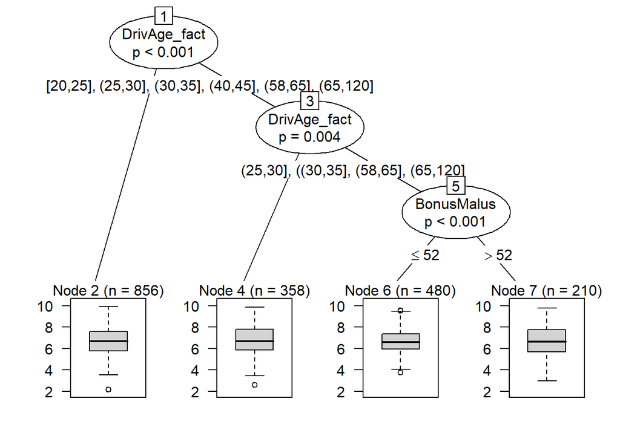

```r
glm_tree2_lognorm_id <- glmtree(log(ClaimAmount) ~ MariStat+Categ+VehUsage+HasKmLimit+ClaimNbResp+ClaimNbNonResp+ClaimNbParking+ClaimNbFireTheft+ClaimNbWindscreen+OutUseNb+RiskArea+BonusMalus|MariStat+Categ+VehUsage+HasKmLimit+ClaimNbResp+ClaimNbNonResp+ClaimNbParking+ClaimNbFireTheft+ClaimNbWindscreen+OutUseNb+RiskArea+BonusMalus+DrivAge_fact,
  data = trainGLM.data, maxdepth = 7, family = gaussian(link = "identity"))

plot(glm_tree2_lognorm_id)
```

```r
summary(glm_tree2_lognorm_id)
```

```
## $`2`
##
## Call:
## glm(formula = log(ClaimAmount) ~ MariStat + Categ + VehUsage +
##     HasKmLimit + ClaimNbResp + ClaimNbNonResp + ClaimNbParking +
##     ClaimNbFireTheft + ClaimNbWindscreen + OutUseNb + RiskArea +
##     BonusMalus)
##
## Coefficients:
##                                 Estimate Std. Error t value Pr(>|t|)
## (Intercept)                     7.648327   0.443484  17.246  < 2e-16 ***
## MariStatOther                  -0.464773   0.147572  -3.149 0.001694 **
## CategCateg1                    -0.594677   0.273915  -2.171 0.030210 *
## CategCateg2                    -0.265926   0.218286  -1.218 0.223475
## CategCateg3                    -1.183585   0.457269  -2.588 0.009810 **
## CategCateg4                    -0.456779   0.242075  -1.887 0.059516 .
## VehUsagePrivate+trip to office -0.585076   0.156373  -3.742 0.000195 ***
## VehUsageProfessional           -0.142768   0.190816  -0.748 0.454550
## VehUsageProfessional run       -0.158724   0.263006  -0.604 0.546340
## HasKmLimit1                     0.794256   0.309184   2.569 0.010375 *
## ClaimNbResp                     0.213375   0.090119   2.368 0.018125 *
## ClaimNbNonResp                  0.087030   0.069295   1.256 0.209492
## ClaimNbParking                  0.228134   0.140274   1.626 0.104253
## ClaimNbFireTheft                0.182721   0.144947   1.261 0.207802
## ClaimNbWindscreen               0.011248   0.064805   0.174 0.862251
## OutUseNb                       -0.118263   0.062038  -1.906 0.056956 .
## RiskAreaZoneRisque2            -0.010470   0.251771  -0.042 0.966840
## RiskAreaZoneRisque3             0.000672   0.258711   0.003 0.997928
## RiskAreaZoneRisque4             0.050656   0.343250   0.148 0.882713
## BonusMalus                     -0.001544   0.003330  -0.464 0.642939
## ---
## Signif. codes:  0 '***' 0.001 '**' 0.01 '*' 0.05 '.' 0.1 ' ' 1
##
## (Dispersion parameter for gaussian family taken to be 1.798173)
##
##     Null deviance: 1603.9  on 855  degrees of freedom
## Residual deviance: 1503.3  on 836  degrees of freedom
## AIC: 2953.3
##
## Number of Fisher Scoring iterations: 2
```

[output cut: 111 more lines]

```
## OutUseNb                        0.021805   0.163988   0.133 0.894363
## RiskAreaZoneRisque2             0.853424   0.610195   1.399 0.163561
## RiskAreaZoneRisque3             1.603965   0.613905   2.613 0.009701 **
## RiskAreaZoneRisque4             1.559607   0.712358   2.189 0.029789 *
## BonusMalus                      0.007588   0.005623   1.349 0.178827
## ---
## Signif. codes:  0 '***' 0.001 '**' 0.01 '*' 0.05 '.' 0.1 ' ' 1
##
## (Dispersion parameter for gaussian family taken to be 1.570404)
##
##     Null deviance: 444.97  on 209  degrees of freedom
## Residual deviance: 298.38  on 190  degrees of freedom
## AIC: 711.72
##
## Number of Fisher Scoring iterations: 2
```

Comparons les AIC

```r
AIC(glm_tree_lognorm_id)
```

```
## [1] 6441.013
```

```r
AIC(glm_tree2_lognorm_id)
```

```
## [1] 6455.042
```

Remarque: si on garde le modèle avec juste les variables seuils, on a

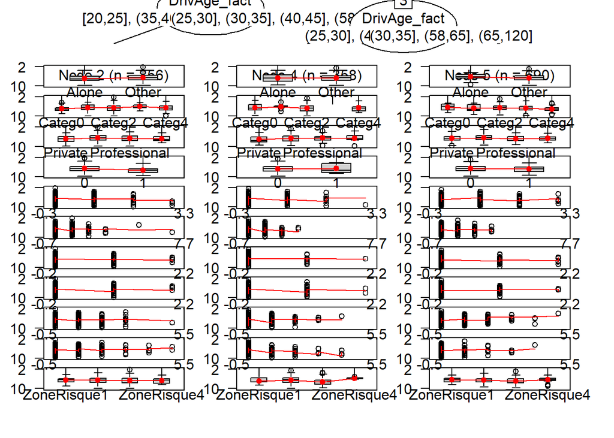

```r
glm_tree3_lognorm_id <- glmtree(log(ClaimAmount) ~ MariStat+Categ+VehUsage+HasKmLimit+ClaimNbResp+ClaimNbNonResp+ClaimNbParking+ClaimNbFireTheft+ClaimNbWindscreen+OutUseNb+RiskArea|BonusMalus+DrivAge_fact,
  data = trainGLM.data, maxdepth = 3, family = gaussian(link = "identity"))

plot(glm_tree3_lognorm_id)
```

```r
summary(glm_tree3_lognorm_id)
```

```
## $`2`
##
## Call:
## glm(formula = log(ClaimAmount) ~ MariStat + Categ + VehUsage +
##     HasKmLimit + ClaimNbResp + ClaimNbNonResp + ClaimNbParking +
##     ClaimNbFireTheft + ClaimNbWindscreen + OutUseNb + RiskArea)
##
## Coefficients:
##                                 Estimate Std. Error t value Pr(>|t|)
## (Intercept)                     7.537921   0.373994  20.155  < 2e-16 ***
## MariStatOther                  -0.440189   0.137658  -3.198 0.001437 **
## CategCateg1                    -0.594475   0.273787  -2.171 0.030188 *
## CategCateg2                    -0.265410   0.218181  -1.216 0.224151
## CategCateg3                    -1.174663   0.456650  -2.572 0.010272 *
## CategCateg4                    -0.455133   0.241936  -1.881 0.060289 .
## VehUsagePrivate+trip to office -0.582686   0.156215  -3.730 0.000204 ***
## VehUsageProfessional           -0.137255   0.190356  -0.721 0.471083
## VehUsageProfessional run       -0.148278   0.261917  -0.566 0.571460
## HasKmLimit1                     0.801606   0.308633   2.597 0.009562 **
## ClaimNbResp                     0.202191   0.086791   2.330 0.020063 *
## ClaimNbNonResp                  0.086912   0.069262   1.255 0.209894
## ClaimNbParking                  0.228959   0.140197   1.633 0.102819
## ClaimNbFireTheft                0.183250   0.144875   1.265 0.206264
## ClaimNbWindscreen               0.014089   0.064485   0.218 0.827103
## OutUseNb                       -0.120173   0.061872  -1.942 0.052440 .
## RiskAreaZoneRisque2            -0.012433   0.251617  -0.049 0.960604
## RiskAreaZoneRisque3            -0.006406   0.258139  -0.025 0.980206
## RiskAreaZoneRisque4             0.044352   0.342820   0.129 0.897094
## ---
## Signif. codes:  0 '***' 0.001 '**' 0.01 '*' 0.05 '.' 0.1 ' ' 1
##
## (Dispersion parameter for gaussian family taken to be 1.796486)
##
##     Null deviance: 1603.9  on 855  degrees of freedom
## Residual deviance: 1503.7  on 837  degrees of freedom
## AIC: 2951.5
##
## Number of Fisher Scoring iterations: 2
##
##
```

[output cut: 63 more lines]

```
## ClaimNbWindscreen              -0.3022894  0.0622876  -4.853 1.51e-06 ***
## OutUseNb                        0.0006106  0.0983052   0.006   0.9950
## RiskAreaZoneRisque2             0.1491868  0.2246801   0.664   0.5069
## RiskAreaZoneRisque3             0.3395978  0.2300362   1.476   0.1403
## RiskAreaZoneRisque4            -0.0462260  0.2902413  -0.159   0.8735
## ---
## Signif. codes:  0 '***' 0.001 '**' 0.01 '*' 0.05 '.' 0.1 ' ' 1
##
## (Dispersion parameter for gaussian family taken to be 1.52022)
##
##     Null deviance: 1133.7  on 689  degrees of freedom
## Residual deviance: 1020.1  on 671  degrees of freedom
## AIC: 2267.9
##
## Number of Fisher Scoring iterations: 2
```

```r
AIC(glm_tree3_lognorm_id)
```

```
## [1] 6482.244
```

#### Avec méthode Tukey

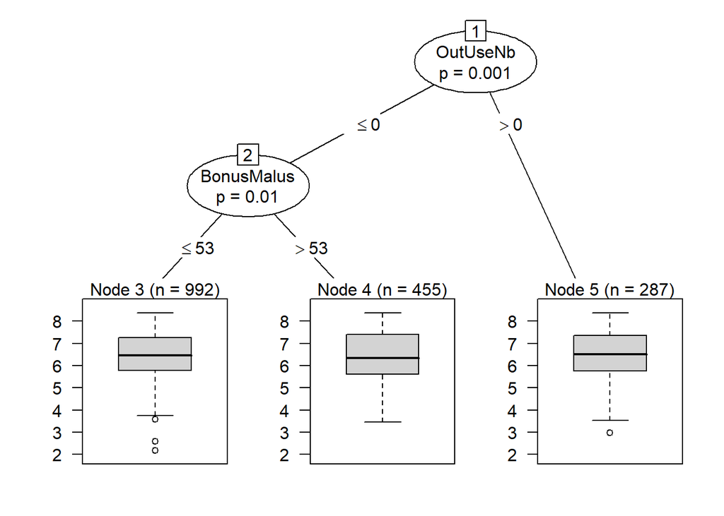

```r
glm_tree_lognorm_id_Tukey <- glmtree(log(ClaimAmount) ~ MariStat+Categ+VehUsage+HasKmLimit+ClaimNbResp+ClaimNbNonResp+ClaimNbParking+ClaimNbFireTheft+ClaimNbWindscreen+OutUseNb+RiskArea+BonusMalus+DrivAge_fact|MariStat+Categ+VehUsage+HasKmLimit+ClaimNbResp+ClaimNbNonResp+ClaimNbParking+ClaimNbFireTheft+ClaimNbWindscreen+OutUseNb+RiskArea+BonusMalus+DrivAge_fact,
  data = train_Tukey, maxdepth = 7, family = gaussian(link = "identity"))
plot(glm_tree_lognorm_id_Tukey)
```

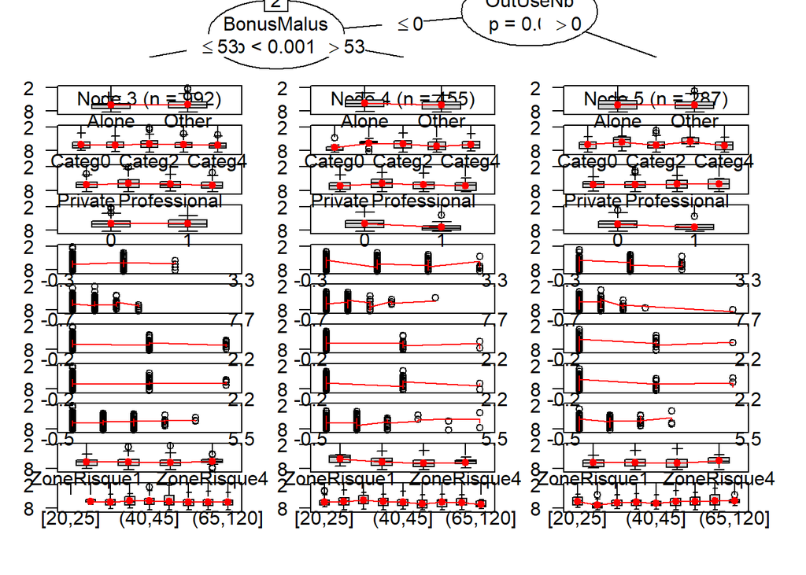

```r
glm_tree2_lognorm_id_Tukey <- glmtree(log(ClaimAmount) ~ MariStat+Categ+VehUsage+HasKmLimit+ClaimNbResp+ClaimNbNonResp+ClaimNbParking+ClaimNbFireTheft+ClaimNbWindscreen+RiskArea+DrivAge_fact|OutUseNb+BonusMalus,
  data = train_Tukey, maxdepth = 7, family = gaussian(link = "identity"))
plot(glm_tree2_lognorm_id_Tukey)
```

```r
AIC(glm_tree2_lognorm_id_Tukey)
```

```
## [1] 5415.921
```

```r
AIC(glm_tree_lognorm_id_Tukey)
```

```
## [1] 5413.817
```

```r
AIC(glm_tree2_lognorm_id_Tukey)
```

```
## [1] 5415.921
```

### B)Lien inverse

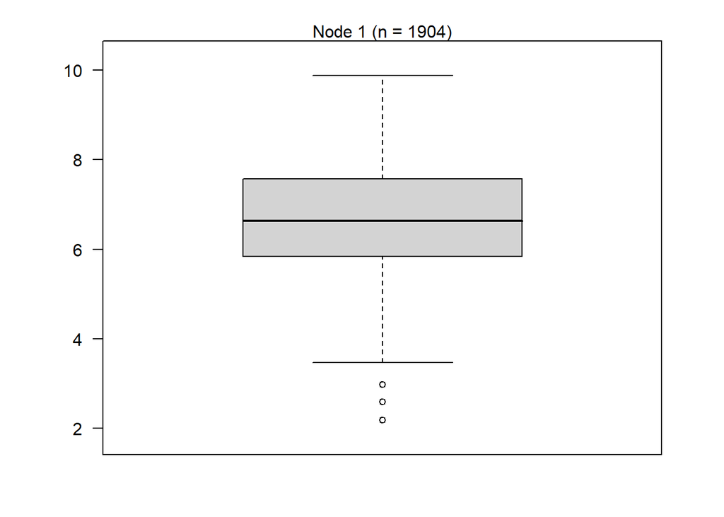

```r
glm_tree_lognorm_inv <- glmtree(log(ClaimAmount) ~ MariStat+Categ+VehUsage+HasKmLimit+ClaimNbResp+ClaimNbNonResp+ClaimNbParking+ClaimNbFireTheft+ClaimNbWindscreen+OutUseNb+RiskArea+BonusMalus+DrivAge_fact+HasKmLimit*ClaimNbNonResp|MariStat+Categ+VehUsage+HasKmLimit+ClaimNbResp+ClaimNbNonResp+ClaimNbParking+ClaimNbFireTheft+ClaimNbWindscreen+OutUseNb+RiskArea+BonusMalus+DrivAge_fact,
  data = trainGLM.data, maxdepth = 7, family = gaussian(link = "inverse"))

plot(glm_tree_lognorm_inv)
```

```r
AIC(glm_tree_lognorm_inv)
```

```
## [1] 6499.314
```

Regardons l’arbre donné par les variables seuils de Tukey

```r
glm_tree2_lognorm_inv <- glmtree(log(ClaimAmount) ~ MariStat+Categ+VehUsage+HasKmLimit+ClaimNbParking+ClaimNbFireTheft+ClaimNbWindscreen+ClaimNbResp+RiskArea+DrivAge_fact+ClaimNbNonResp+RiskArea+DrivAge_fact|BonusMalus+OutUseNb,
  data = trainGLM.data, maxdepth = 7, family = gaussian(link = "inverse"))
```

```
## Error in chol.default(meat) :
##   le mineur dominant d'ordre 25 n'est pas défini positif
```

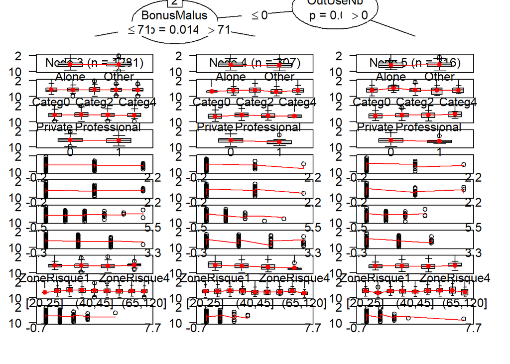

```r
plot(glm_tree2_lognorm_inv)
```

Apparition d’un message d’erreur

#### Avec methode Tukey

```r
glm_tree_lognorm_inv_Tukey <- glmtree(log(ClaimAmount) ~ MariStat+Categ+VehUsage+HasKmLimit+ClaimNbResp+ClaimNbNonResp+ClaimNbParking+ClaimNbFireTheft+ClaimNbWindscreen+OutUseNb+RiskArea+BonusMalus+DrivAge_fact|MariStat+Categ+VehUsage+HasKmLimit+ClaimNbResp+ClaimNbNonResp+ClaimNbParking+ClaimNbFireTheft+ClaimNbWindscreen+OutUseNb+RiskArea+BonusMalus+DrivAge_fact,
  data = train_Tukey, maxdepth = 7, family = gaussian(link = "inverse"))
```

```
## Error in root.matrix(switch(vcov, opg = chol2inv(chol(meat)), info = bread,  :
##   Matrix is not positive semidefinite
```

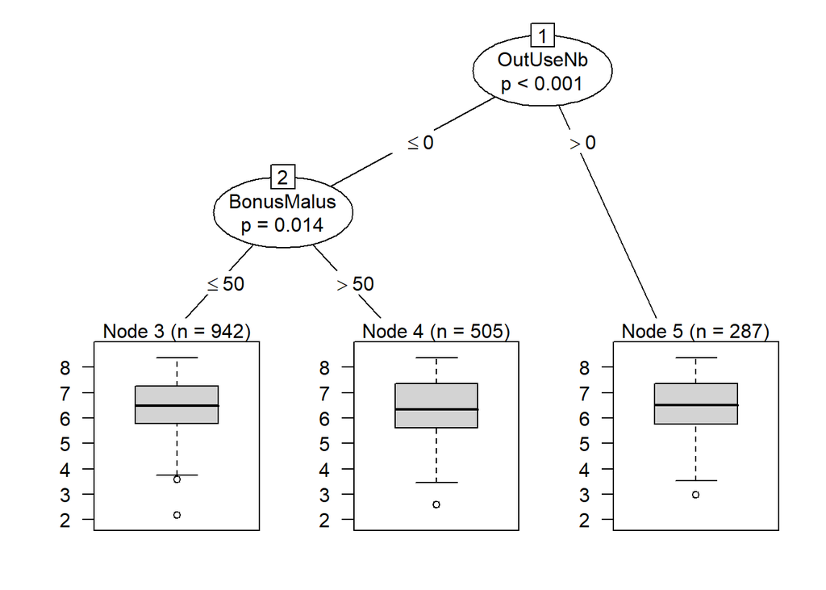

```r
plot(glm_tree_lognorm_inv_Tukey)
```

On a l’apparition du message d’erreur :

```
Error in root.matrix(switch(vcov, opg = chol2inv(chol(meat)), info = bread,  :
  Matrix is not positive semidefinite
```

Regardons l’arbre quand les variables n’apparaissent qu’une seul fois

```r
glm_tree2_lognorm_inv_Tukey <- glmtree(log(ClaimAmount) ~ MariStat+Categ+VehUsage+HasKmLimit+ClaimNbResp+ClaimNbNonResp+ClaimNbParking+ClaimNbFireTheft+ClaimNbWindscreen+RiskArea+DrivAge_fact|OutUseNb+BonusMalus,
  data = train_Tukey, maxdepth = 7, family = gaussian(link = "inverse"))
```

```
## Error in root.matrix(switch(vcov, opg = chol2inv(chol(meat)), info = bread,  :
##   Matrix is not positive semidefinite
```

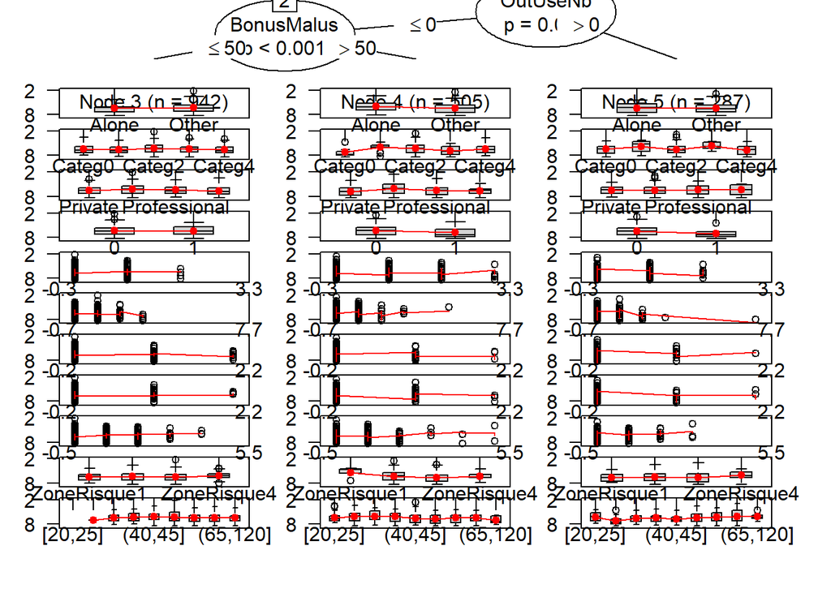

```r
plot(glm_tree2_lognorm_inv_Tukey)
```

Le même message d’erreur apparaît

### C) Lien log

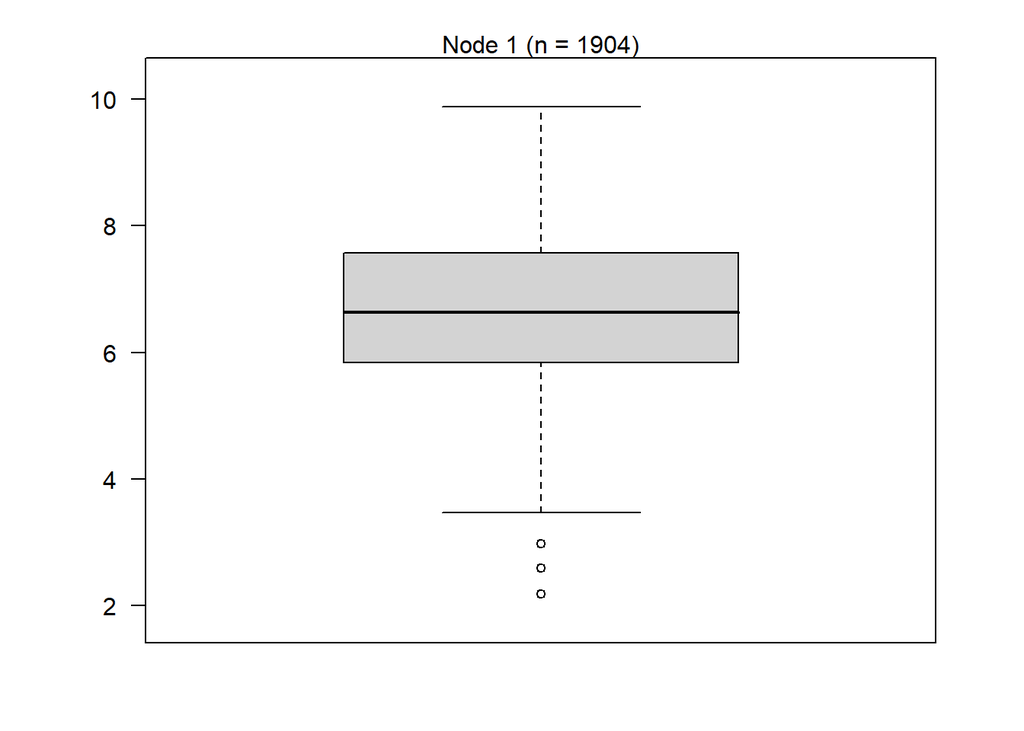

```r
glm_tree_lognorm_log <- glmtree(log(ClaimAmount) ~ MariStat+Categ+VehUsage+HasKmLimit+ClaimNbResp+ClaimNbNonResp+ClaimNbParking+ClaimNbFireTheft+ClaimNbWindscreen+OutUseNb+RiskArea+BonusMalus+DrivAge_fact|MariStat+Categ+VehUsage+HasKmLimit+ClaimNbResp+ClaimNbNonResp+ClaimNbParking+ClaimNbFireTheft+ClaimNbWindscreen+OutUseNb+RiskArea+BonusMalus+DrivAge_fact,
  data = trainGLM.data, maxdepth = 7, family = gaussian(link = "log"))

plot(glm_tree_lognorm_log)
```

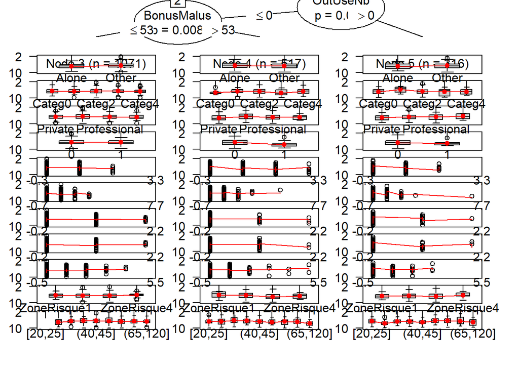

```r
glm_tree2_lognorm_log <- glmtree(log(ClaimAmount) ~ MariStat+Categ+VehUsage+HasKmLimit+ClaimNbResp+ClaimNbNonResp+ClaimNbParking+ClaimNbFireTheft+ClaimNbWindscreen+RiskArea+DrivAge_fact|OutUseNb+BonusMalus,
  data = trainGLM.data, maxdepth = 7, family = gaussian(link = "log"))

plot(glm_tree2_lognorm_log)
```

```r
AIC(glm_tree_lognorm_log)
```

```
## [1] 6500.527
```

```r
AIC(glm_tree2_lognorm_log)
```

```
## [1] 6492.041
```

#### Avec methode Tukey

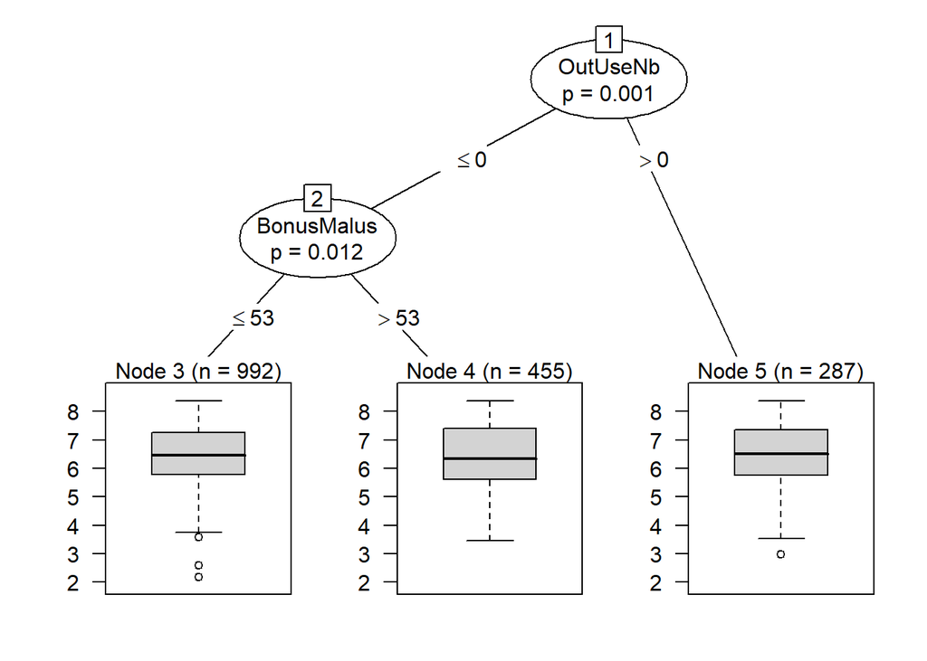

```r
glm_tree_lognorm_log_Tukey <- glmtree(log(ClaimAmount) ~ MariStat+Categ+VehUsage+HasKmLimit+ClaimNbResp+ClaimNbNonResp+ClaimNbParking+ClaimNbFireTheft+ClaimNbWindscreen+OutUseNb+RiskArea+BonusMalus+DrivAge_fact|MariStat+Categ+VehUsage+HasKmLimit+ClaimNbResp+ClaimNbNonResp+ClaimNbParking+ClaimNbFireTheft+ClaimNbWindscreen+OutUseNb+RiskArea+BonusMalus+DrivAge_fact,
  data = train_Tukey, maxdepth = 7, family = gaussian(link = "log"))
plot(glm_tree_lognorm_log_Tukey)
```

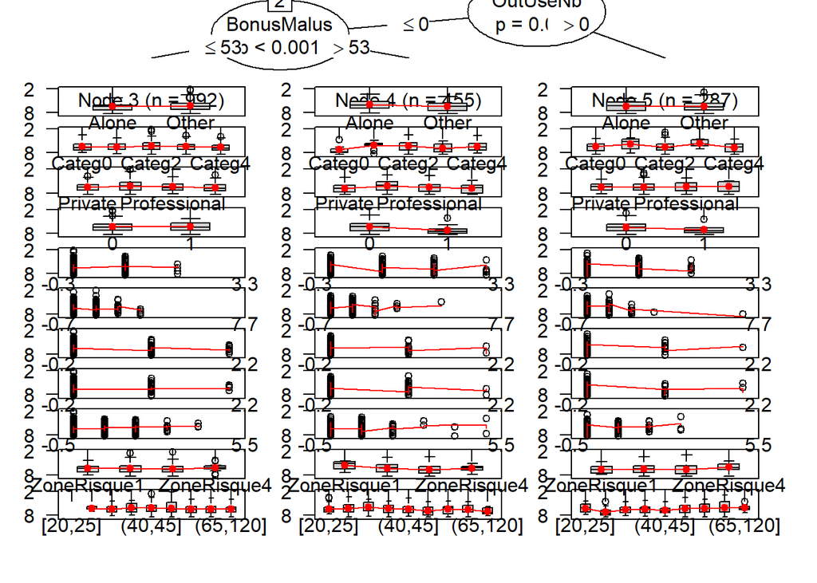

```r
glm_tree2_lognorm_log_Tukey <- glmtree(log(ClaimAmount) ~ MariStat+Categ+VehUsage+HasKmLimit+ClaimNbResp+ClaimNbNonResp+ClaimNbParking+ClaimNbFireTheft+ClaimNbWindscreen+RiskArea+DrivAge_fact|OutUseNb+BonusMalus,
  data = train_Tukey, maxdepth = 7, family = gaussian(link = "log"))
plot(glm_tree2_lognorm_log_Tukey)
```

```r
AIC(glm_tree_lognorm_log_Tukey)
```

```
## [1] 5416.586
```

```r
AIC(glm_tree2_lognorm_log_Tukey)
```

```
## [1] 5417.731
```

## III) GLM tree Gamma

### A) Lien inverse

#### 1) Sur l’échantillon trainGLM.data

```r
glm_tree_gamma_inv <- glmtree(ClaimAmount ~ MariStat+Categ+VehUsage+HasKmLimit+RiskArea+ClaimNbParking+ClaimNbFireTheft+ClaimNbWindscreen+DrivAge_fact|ClaimNbResp+ClaimNbNonResp+OutUseNb+BonusMalus,
  data = trainGLM.data, maxdepth = 7, family = Gamma(link = "inverse"))
```

```
## Error: impossible de trouver un jeu de coefficients correct : prière de fournir des valeurs initiales
```

```r
plot(glm_tree_gamma_inv)
```

```
## Error in h(simpleError(msg, call)): erreur d'ï¿½valuation de l'argument 'x' lors de la sï¿½lection d'une mï¿½thode pour la fonction 'plot' : objet 'glm_tree_gamma_inv' introuvable
```

Apparition du message :

```
Error: impossible de trouver un jeu de coefficients correct : prière de fournir des valeurs initiales
```

De la même façon que notre code pour les GLM nous avons essayé d’affecter des valeurs initiales mais aucun résultat n’a abouti. Nous avons testé d’autres arbres mais ceux-ci renvoient aussi la même erreur et un arbre d’un seul noeud

#### 2) Sur l’échantillon train_Tukey

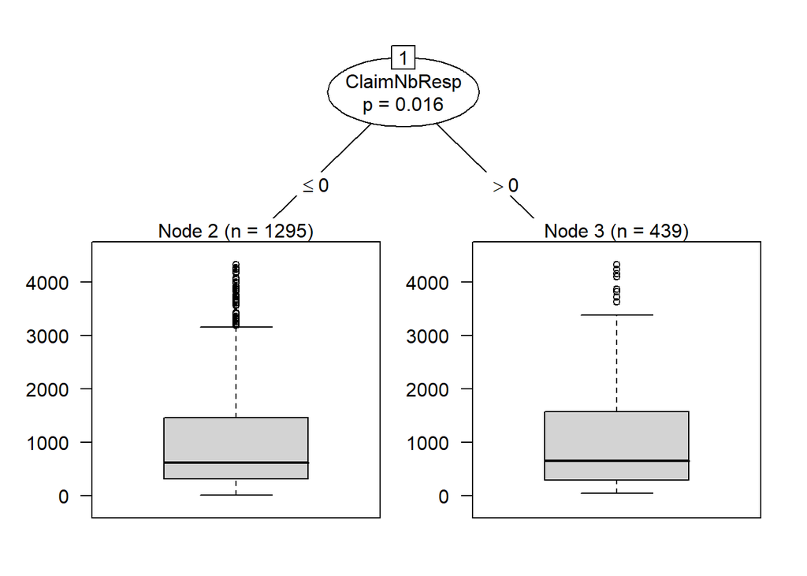

```r
glm_tree_gamma_inv_Tukey <- glmtree(ClaimAmount ~ MariStat+Categ+VehUsage+HasKmLimit+ClaimNbResp+ClaimNbNonResp+ClaimNbParking+ClaimNbFireTheft+ClaimNbWindscreen+OutUseNb+RiskArea+BonusMalus+DrivAge_fact|MariStat+Categ+VehUsage+HasKmLimit+ClaimNbResp+ClaimNbNonResp+ClaimNbParking+ClaimNbFireTheft+ClaimNbWindscreen+OutUseNb+RiskArea+BonusMalus+DrivAge_fact,
  data = train_Tukey, maxdepth = 7, family = Gamma(link = "inverse"))
plot(glm_tree_gamma_inv_Tukey)
```

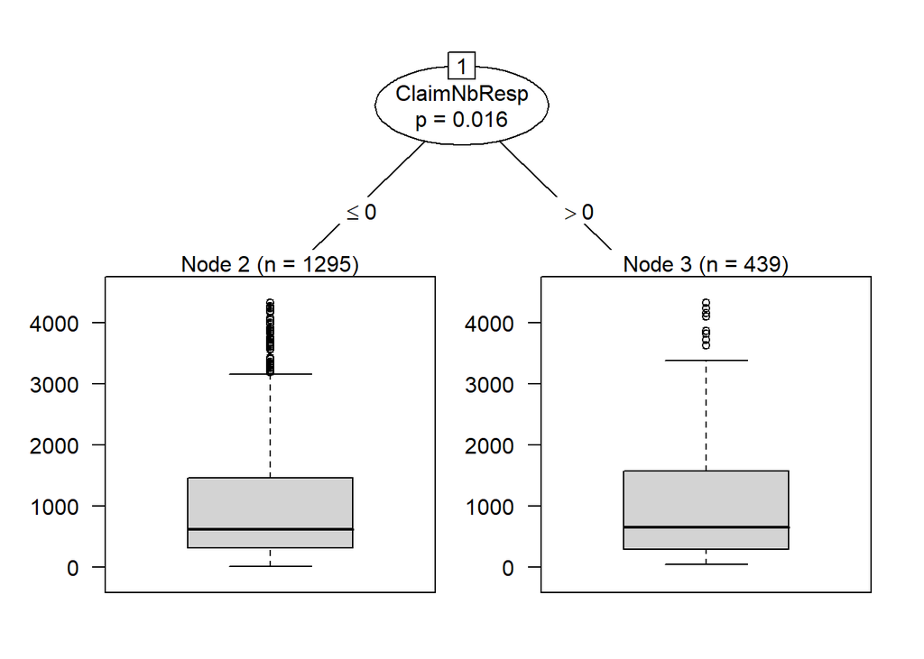

```r
glm_tree2_gamma_inv_Tukey <- glmtree(ClaimAmount ~ MariStat+Categ+VehUsage+HasKmLimit+ClaimNbResp+ClaimNbNonResp+ClaimNbParking+ClaimNbFireTheft+ClaimNbWindscreen+OutUseNb+RiskArea+BonusMalus+DrivAge_fact|ClaimNbResp,
  data = train_Tukey, maxdepth = 7, family = Gamma(link = "inverse"))
plot(glm_tree_gamma_inv_Tukey)
```

```r
AIC(glm_tree_gamma_inv_Tukey)
```

```
## [1] 27617.86
```

```r
AIC(glm_tree2_gamma_inv_Tukey)
```

```
## [1] 27617.86
```

### B) Lien log

```r
glm_tree_gamma_log <- glmtree(ClaimAmount ~ MariStat+Categ+VehUsage+HasKmLimit+ClaimNbResp+ClaimNbNonResp+ClaimNbParking+ClaimNbFireTheft+ClaimNbWindscreen+OutUseNb+RiskArea+BonusMalus+DrivAge_fact|MariStat+Categ+VehUsage+HasKmLimit+ClaimNbResp+ClaimNbNonResp+ClaimNbParking+ClaimNbFireTheft+ClaimNbWindscreen+OutUseNb+RiskArea+BonusMalus+DrivAge_fact,
  data = trainGLM.data, maxdepth = 7, family = Gamma(link = "log"))
```

[output not shown]

[output cut: 24 more lines]

[output not shown]

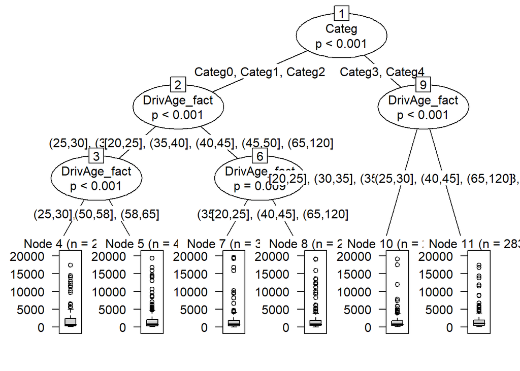

```r
plot(glm_tree_gamma_log)
```

Attention, nous obtenons un arbre GLM mais aussi plusieurs messages d’erreurs

[output not shown]

Enlevons les variables seuils:

```r
glm_tree2_gamma_log <- glmtree(ClaimAmount ~ MariStat+VehUsage+HasKmLimit+ClaimNbResp+ClaimNbNonResp+ClaimNbParking+ClaimNbFireTheft+ClaimNbWindscreen+OutUseNb+RiskArea+BonusMalus|Categ+DrivAge_fact,
  data = trainGLM.data, maxdepth = 7, family = Gamma(link = "log"))
```

[figure not shown]

```r
plot(glm_tree2_gamma_log)
```

De la même manière, nous obtenons un arbre GLM mais aussi le même message d’erreur comme lesquels les glm n’ont pas convergé.

#### Avec methode Tukey

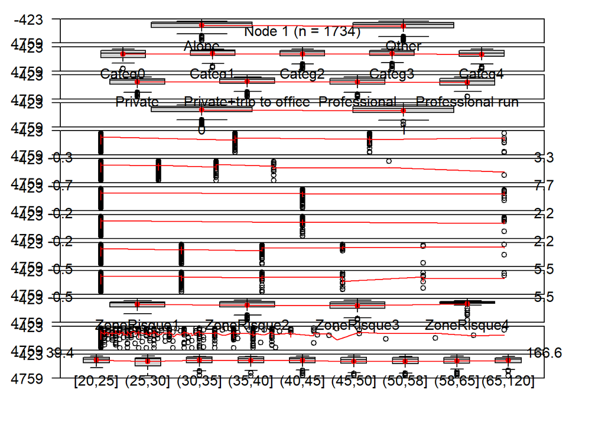

```r
glm_tree_gamma_log_Tukey <- glmtree(ClaimAmount ~ MariStat+Categ+VehUsage+HasKmLimit+ClaimNbResp+ClaimNbNonResp+ClaimNbParking+ClaimNbFireTheft+ClaimNbWindscreen+OutUseNb+RiskArea+BonusMalus+DrivAge_fact|Categ+DrivAge_fact,
  data = train_Tukey, maxdepth = 7, family = Gamma(link = "log"))
plot(glm_tree_gamma_log_Tukey)
```

Apparition d’un arbre à un seul noeud

```r
summary(glm_tree_gamma_log_Tukey)
```

```
##
## Call:
## glm(formula = ClaimAmount ~ MariStat + Categ + VehUsage + HasKmLimit +
##     ClaimNbResp + ClaimNbNonResp + ClaimNbParking + ClaimNbFireTheft +
##     ClaimNbWindscreen + OutUseNb + RiskArea + BonusMalus + DrivAge_fact)
##
## Coefficients:
##                                 Estimate Std. Error t value Pr(>|t|)
## (Intercept)                     6.426704   0.282716  22.732  < 2e-16 ***
## MariStatOther                   0.149025   0.079267   1.880 0.060275 .
## CategCateg1                    -0.203773   0.159222  -1.280 0.200786
## CategCateg2                    -0.047764   0.126903  -0.376 0.706681
## CategCateg3                    -0.149861   0.168761  -0.888 0.374662
## CategCateg4                    -0.043210   0.137120  -0.315 0.752706
## VehUsagePrivate+trip to office -0.267017   0.085376  -3.128 0.001793 **
## VehUsageProfessional           -0.124256   0.102001  -1.218 0.223325
## VehUsageProfessional run       -0.014600   0.143610  -0.102 0.919037
## HasKmLimit1                     0.226822   0.111191   2.040 0.041511 *
## ClaimNbResp                     0.054283   0.047651   1.139 0.254784
## ClaimNbNonResp                  0.104889   0.036714   2.857 0.004329 **
## ClaimNbParking                  0.088285   0.069127   1.277 0.201726
## ClaimNbFireTheft                0.067977   0.072588   0.936 0.349158
## ClaimNbWindscreen              -0.108077   0.032213  -3.355 0.000811 ***
## OutUseNb                        0.054108   0.035227   1.536 0.124724
## RiskAreaZoneRisque2             0.151492   0.125407   1.208 0.227213
## RiskAreaZoneRisque3             0.256108   0.129003   1.985 0.047273 *
## RiskAreaZoneRisque4            -0.105074   0.163640  -0.642 0.520892
## BonusMalus                      0.003732   0.002108   1.771 0.076787 .
## DrivAge_fact(25,30]             0.286156   0.152287   1.879 0.060407 .
## DrivAge_fact(30,35]             0.069033   0.154293   0.447 0.654629
## DrivAge_fact(35,40]             0.061577   0.158298   0.389 0.697329
## DrivAge_fact(40,45]             0.175752   0.160457   1.095 0.273531
## DrivAge_fact(45,50]             0.278169   0.161329   1.724 0.084847 .
## DrivAge_fact(50,58]             0.314028   0.158277   1.984 0.047411 *
## DrivAge_fact(58,65]             0.178620   0.165609   1.079 0.280936
## DrivAge_fact(65,120]            0.028296   0.185525   0.153 0.878797
## ---
## Signif. codes:  0 '***' 0.001 '**' 0.01 '*' 0.05 '.' 0.1 ' ' 1
##
## (Dispersion parameter for Gamma family taken to be 0.9616042)
##
##     Null deviance: 1959.4  on 1733  degrees of freedom
## Residual deviance: 1864.8  on 1706  degrees of freedom
## AIC: 27615
##
## Number of Fisher Scoring iterations: 7
```

### C) Lien Identite

```r
glm_tree_gamma_id <- glmtree(ClaimAmount ~ MariStat+Categ+VehUsage+HasKmLimit+ClaimNbResp+ClaimNbNonResp+ClaimNbParking+ClaimNbFireTheft+ClaimNbWindscreen+RiskArea+DrivAge_fact| OutUseNb+BonusMalus, data = trainGLM.data, maxdepth = 7, family = Gamma(link = "identity"))
```

Peu importe les arbres que nous ferons, nous avons ce message d’erreur ou le message d’erreur suivant

Message d’erreur :

```
Error: impossible de trouver un jeu de coefficients correct : prière de fournir des valeurs initiales
```

#### Avec methode Tukey

```r
glm_tree_gamma_id_Tukey <- glmtree(ClaimAmount ~ MariStat+Categ+VehUsage+HasKmLimit+ClaimNbResp+ClaimNbNonResp+ClaimNbParking+ClaimNbFireTheft+ClaimNbWindscreen+RiskArea+DrivAge_fact| OutUseNb+BonusMalus,
  data = train_Tukey, maxdepth = 7, family = Gamma(link = "identity"))
```

```
## Error: impossible de trouver un jeu de coefficients correct : prière de fournir des valeurs initiales
```

```r
plot(glm_tree_gamma_id_Tukey)
```

```
## Error in h(simpleError(msg, call)): erreur d'ï¿½valuation de l'argument 'x' lors de la sï¿½lection d'une mï¿½thode pour la fonction 'plot' : objet 'glm_tree_gamma_id_Tukey' introuvable
```

Message d’erreur :

```
Avis : NaNs producedAvis : le pas a été tronqué à cause de la divergenceAvis : NaNs producedAvis : NaNs produced
```

## IV) GLM tree Inverse gaussienne

### A) Lien 1/mu^2

```r
glm_tree_invgauss_mu <- glmtree(ClaimAmount ~ MariStat+Categ+VehUsage+HasKmLimit+ClaimNbNonResp+ClaimNbParking+ClaimNbFireTheft+ClaimNbWindscreen+RiskArea+DrivAge_fact|ClaimNbResp+OutUseNb+BonusMalus+DrivAge_fact, data = trainGLM.data, maxdepth = 7, family = inverse.gaussian(link = "1/mu^2"))
```

```
## Error: impossible de trouver un jeu de coefficients correct : prière de fournir des valeurs initiales
```

Message d’erreur :

```
Error: impossible de trouver un jeu de coefficients correct : prière de fournir des valeurs initiales
```

#### Avec methode Tukey

```r
glm_tree_invgauss_mu_Tukey <- glmtree(ClaimAmount ~ MariStat+Categ+VehUsage+HasKmLimit+ClaimNbNonResp+ClaimNbParking+ClaimNbFireTheft+ClaimNbWindscreen+RiskArea+DrivAge_fact|ClaimNbResp+OutUseNb+BonusMalus+DrivAge_fact,
  data = train_Tukey, maxdepth = 7, family = inverse.gaussian(link = "1/mu^2"))
```

```
## Error: impossible de trouver un jeu de coefficients correct : prière de fournir des valeurs initiales
```

Message d’erreur :

```
Error: impossible de trouver un jeu de coefficients correct : prière de fournir des valeurs initiales
```

### B) Lien identité

```r
glm_tree_invgauss_id <- glmtree(ClaimAmount ~ MariStat+Categ+VehUsage+HasKmLimit+ClaimNbNonResp+ClaimNbParking+ClaimNbFireTheft+ClaimNbWindscreen+RiskArea+DrivAge_fact|ClaimNbResp+OutUseNb+BonusMalus+DrivAge_fact, data = trainGLM.data, maxdepth = 7, family = inverse.gaussian(link = "identity"))
```

```
## Error in glm.fit(x = structure(c(1, 1, 1, 1, 1, 1, 1, 1, 1, 1, 1, 1, 1, : NA/NaN/Inf dans 'x'
```

De la même façon, nous obtenons quelques soient l’arbre le message d’erreur suivant:

```
Error in glm.fit(x = c(1, 1, 1, 1, 1, 1, 1, 1, 1, 1, 1, 1, 1, 1, 1, 1, :
NA/NaN/Inf dans 'x'
```

trainGLM.data n’ayant pas de valeurs NA/NaN/Inf (l’algorithme fonctionnant pour d’autres lois et d’autres liens), on en conclut que la loi inverse gaussienne avec le lien identité ne fit tout simplement pas à notre échantillon de données

#### Avec methode Tukey

```r
glm_tree_invgauss_id_Tukey <- glmtree(ClaimAmount ~ MariStat+Categ+VehUsage+HasKmLimit+ClaimNbNonResp+ClaimNbParking+ClaimNbFireTheft+ClaimNbWindscreen+RiskArea+DrivAge_fact|ClaimNbResp+OutUseNb+BonusMalus+DrivAge_fact,
  data = train_Tukey, maxdepth = 15, family = inverse.gaussian(link = "identity"))
```

```
## Error in glm.fit(x = structure(c(1, 1, 1, 1, 1, 1, 1, 1, 1, 1, 1, 1, 1, : NA/NaN/Inf dans 'x'
```

Message d’erreur :

```
Error in glm.fit(x = c(1, 1, 1, 1, 1, 1, 1, 1, 1, 1, 1, 1, 1, 1, 1, 1, :
NA/NaN/Inf dans 'x'
```

### C) Lien log

```r
glm_tree_invgauss_log <- glmtree(ClaimAmount ~ MariStat+Categ+VehUsage+HasKmLimit+ClaimNbNonResp+ClaimNbParking+ClaimNbFireTheft+ClaimNbWindscreen+RiskArea+DrivAge_fact|ClaimNbResp+OutUseNb+BonusMalus+DrivAge_fact, data = trainGLM.data, maxdepth = 7, family = inverse.gaussian(link = "log"))
```

```
## Error: boucle interne 1 ; impossible de corriger le pas
```

Message d’erreur :

```
Error: boucle interne 1 ; impossible de corriger le pas
```

#### Avec methode Tukey

```r
glm_tree_invgauss_log_Tukey <- glmtree(ClaimAmount ~ MariStat+Categ+VehUsage+HasKmLimit+ClaimNbNonResp+ClaimNbParking+ClaimNbFireTheft+ClaimNbWindscreen+RiskArea+DrivAge_fact|ClaimNbResp+OutUseNb+BonusMalus+DrivAge_fact,
  data = train_Tukey, maxdepth = 7, family = inverse.gaussian(link = "log"))
```

```
## Error: boucle interne 1 ; impossible de corriger le pas
```

Message d’erreur :

```
Error: boucle interne 1 ; impossible de corriger le pas
```

### D) Lien inverse

```r
glm_tree_invgauss_inv <- glmtree(ClaimAmount ~ MariStat+Categ+VehUsage+HasKmLimit+ClaimNbNonResp+ClaimNbParking+ClaimNbFireTheft+ClaimNbWindscreen+RiskArea+DrivAge_fact|ClaimNbResp+OutUseNb+BonusMalus+DrivAge_fact, data = trainGLM.data, maxdepth = 7, family = inverse.gaussian(link = "inverse"))
```

```
## Error in glm.fit(x = structure(c(1, 1, 1, 1, 1, 1, 1, 1, 1, 1, 1, 1, 1, : NA/NaN/Inf dans 'x'
```

Message d’erreur :

```
Error in glm.fit(x = c(1, 1, 1, 1, 1, 1, 1, 1, 1, 1, 1, 1, 1, 1, 1, 1, :
NA/NaN/Inf dans 'x'
```

#### Avec methode Tukey

```r
glm_tree_invgauss_inv_Tukey <- glmtree(ClaimAmount ~ MariStat+Categ+VehUsage+HasKmLimit+ClaimNbNonResp+ClaimNbParking+ClaimNbFireTheft+ClaimNbWindscreen+RiskArea+DrivAge_fact|ClaimNbResp+OutUseNb+BonusMalus,
  data = train_Tukey, maxdepth = 15, family = inverse.gaussian(link = "inverse"))
```

```
## Error in glm.fit(x = structure(c(1, 1, 1, 1, 1, 1, 1, 1, 1, 1, 1, 1, 1, : NA/NaN/Inf dans 'x'
```

```r
plot(glm_tree_invgauss_inv_Tukey)
```

```
## Error in h(simpleError(msg, call)): erreur d'ï¿½valuation de l'argument 'x' lors de la sï¿½lection d'une mï¿½thode pour la fonction 'plot' : objet 'glm_tree_invgauss_inv_Tukey' introuvable
```

# Arbre GLM final

## MSE

```r
predglmT <- predict(glm_tree3_lognorm_id, newdata = testGLM.data)
mse <- mean((predglmT - testGLM.data$ClaimAmount)^2)
mse
```

```
## [1] 11714601
```

## RMSE

```r
rmse <- sqrt(mse)
rmse
```

```
## [1] 3422.66
```

## MAE

```r
mae <- mean(abs(predglmT - testGLM.data$ClaimAmount))
mae
```

```
## [1] 1875.071
```